# Reproducible Research: Peer Assessment 1

JMTX

18 juillet 2020

## Loading and preprocessing the data

```r
#load the library
library(dplyr)
library(lubridate)
library(ggplot2)
```

1. **Load the data (i.e.read.csv())**

```r
#knitr::opts_knit$get("base.dir")
#knitr::opts_knit$get("base.url")
#knitr::opts_chunk$get("fig.path")
#-----------------------------------------------------------------------------------------------
# Step 1: Load the data
#
#Note: fill the "project_dir" variable with path of your unziped project repository
#-----------------------------------------------------------------------------------------------

#go to project repository
project_dir="."
setwd(project_dir)

#read the data
data_activity<- read.csv("activity.csv")
```

2. **Process/transform the data (if necessary) into a format suitable for your analysis**

0 data process/transform was used here. (Maybe a conversion of date variable into date format could be interesting).

## What is mean total number of steps taken per day?

1. **Calculate the total number of steps taken per day**

```r
#-----------------------------------------------------------------------------------------------
# Step 2: plot the Histogram of the total number of steps taken each day
#
#-----------------------------------------------------------------------------------------------
#group data by date and compute the sum of the steps for each day
df_sum_steps<-data_activity%>%group_by(date)%>%summarize(sum_steps=sum(steps,na.rm=TRUE))
```

2. **Make a histogram of the total number of steps taken each day**

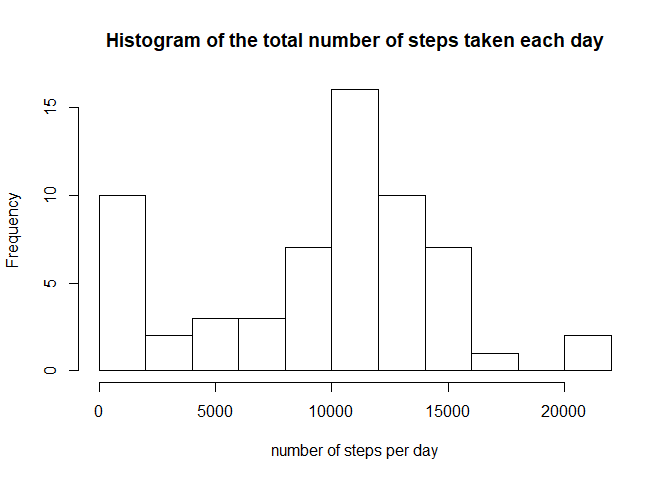

```r
#plot the Histogram of the total number of steps taken each day
#with( df_sum_steps, barplot(sum_steps~date, main="Histogram of the total number of steps taken each day", ylab="number of steps"))
with( df_sum_steps, hist(sum_steps,,breaks=10,main="Histogram of the total number of steps taken each day", xlab="number of steps per day"))
```

3. **Calculate and report the mean and median of the total number of steps taken per day**

```r
#------------------------------------------------------------------------------------------------
# Step 3: Calculate and report the mean and median total number of steps taken per day
#------------------------------------------------------------------------------------------------
df_mm_day<-df_sum_steps%>%summarize(mean_step = mean(sum_steps,na.rm=TRUE),median_step=median(sum_steps,na.rm=TRUE))
```

The **mean** number of steps taken per day is 9354 and the **median** number of steps taken per day is 10395.

## What is the average daily activity pattern?

1. **Make a time series plot (i.e. type = “l”) of the 5-minute interval (x-axis) and the average number of steps taken, averaged across all days (y-axis)**

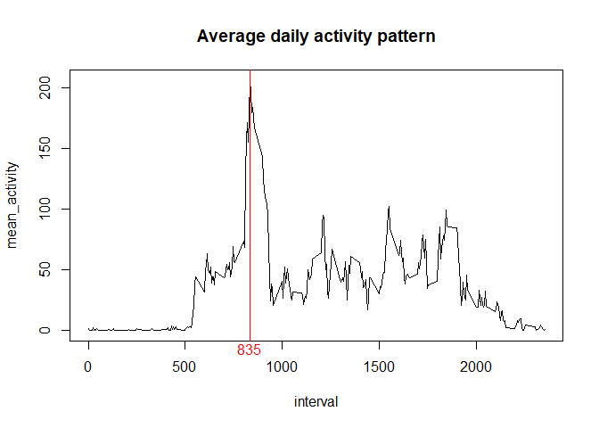

```r
#------------------------------------------------------------------------------------------------
# Step4: Time series plot of the average number of steps taken
#-------------------------------------------------------------------------------------------------
df_average_day_activity<-data_activity%>%group_by(interval)%>%summarize(mean_activity=mean(steps,na.rm=TRUE))
with(df_average_day_activity,plot(mean_activity~interval,type="l",main="Average daily activity pattern"))

#------------------------------------------------------------------------------------------------------
# Step 5: The 5-minute interval that, on average, contains the maximum number of steps
#------------------------------------------------------------------------------------------------------

max_interval<-df_average_day_activity[which.max(df_average_day_activity$mean_activity),1]
abline(v=max_interval,col="red")
#axis(side=1,at=max_interval,col="red",col.lab="red")
mtext(max_interval,at = max_interval,col="red",side=1 )
```

2. **Which 5-minute interval, on average across all the days in the dataset, contains the maximum number of steps?**

According to the previous graphic, the 5-minute interval, which on average across all the days in the dataset contains the maximum number of steps is the 835th.

## Imputing missing values

1. **Calculate and report the total number of missing values in the dataset (i.e. the total number of rows with NAs)**

```r
#--------------------------------------------------------------------------------------------------------
# Step 6: Code to describe and show a strategy for imputing missing data
#--------------------------------------------------------------------------------------------------------
NA_number<-sum(is.na(data_activity$steps))
```

The number of rows which contains NA values is **2304**.

2. **Devise a strategy for filling in all of the missing values in the dataset. The strategy does not need to be sophisticated. For example, you could use the mean/median for that day, or the mean for that 5-minute interval, etc.**

The strategy chosen to fill missing steps values is to replace NA with the average value of steps for this interval computed in the average daily pattern (variable: df_average_day_activity).

3. **Create a new dataset that is equal to the original dataset but with the missing data filled in.**

```r
NA_rows <- is.na(data_activity)
#copy the original data
data_activity2<-data_activity
#The strategy chosen to fill missing steps values is to replace NA with the average value of steps
#for this interval computed in the average daily pattern (variable: df_average_day_activity).
data_activity2[NA_rows,1] <- df_average_day_activity[match(data_activity2[NA_rows,3],
                            df_average_day_activity$interval),2]
```

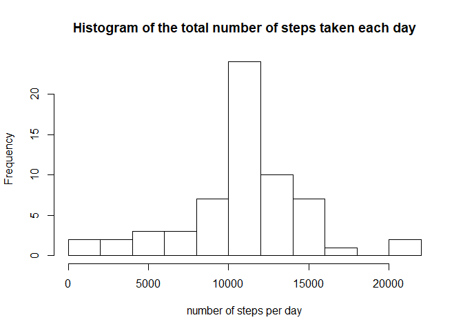

```r
#------------------------------------------------------------------------------------------------
# Step 7: Histogram of the total number of steps taken each day after missing values are imputed
#------------------------------------------------------------------------------------------------
#group data by date and compute the sum of the steps for each day
df_sum_steps2<-data_activity2%>%group_by(date)%>%summarize(sum_steps=sum(steps,na.rm=TRUE))

#plot the Histogram of the total number of steps taken each day
#with( df_sum_steps2, barplot(sum_steps~date, main="Histogram of the total number of steps taken each day", ylab="number of steps"))
with( df_sum_steps2, hist(sum_steps,,breaks=10,main="Histogram of the total number of steps taken each day", xlab="number of steps per day"))
```

```r
#Calculate and report the mean and median total number of steps taken per day
#------------------------------------------------------------------------------------------------
df_mm_day2<-df_sum_steps2%>%summarize(mean_step = mean(sum_steps,na.rm=TRUE),median_step=median(sum_steps,na.rm=TRUE))
```

## Are there differences in activity patterns between weekdays and weekends?

1. **Create a new factor variable in the dataset with two levels – “weekday” and “weekend” indicating whether a given date is a weekday or weekend day.**

```r
#------------------------------------------------------------------------------------------------
# Step 8: Panel plot comparing the average number of steps taken per 5-minute interval across weekdays and weekends
#---------------------------------------------------------------------------------------------------
#Create a new factor variable in the dataset with two levels – “weekday” and “weekend” indicating whether a given
#date is a weekday or weekend day
df2<-data_activity2
df2<-mutate(df2,weekdays = as.factor(sapply(as.POSIXlt(data_activity2$date)$wday,
                               function(x) if (x==6 | x==0){"weekend"} else {"weekday"})))
```

2. *Make a panel plot containing a time series plot (i.e. type = “l”) of the 5-minute interval (x-axis) and the average number of steps taken, averaged across all weekday days or weekend days (y-axis). See the README file in the GitHub repository to see an example of what this plot should look like using simulated data.*

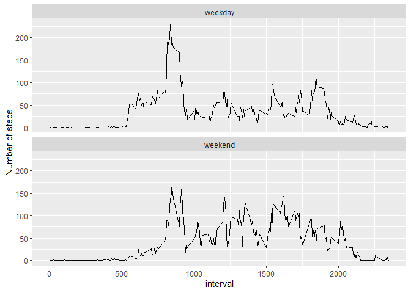

```r
#group by weekdays and interval then compute the average activity pattern for both type of days
df_average<-df2%>%group_by(weekdays,interval)%>%summarize(mean_activity=mean(steps,na.rm=TRUE))

#plot the difference dayly pattern for weekend and weekday using ggplot2
g<-ggplot(df_average,aes(interval,mean_activity))
g + geom_line() + facet_wrap(weekdays~.,nrow=2,ncol=1, strip.position="top")+ylab("Number of steps")#+  facet_grid(weekdays~.,switch="both")+facet_wrap(facets, strip.position="right")
```